# Project no. 1

Jakub Lis, 305744

# Investigating the distribution of alcohol variable

To investigate the distribution of one variable we can use column histogram. It shows how much value goes into a given bin.

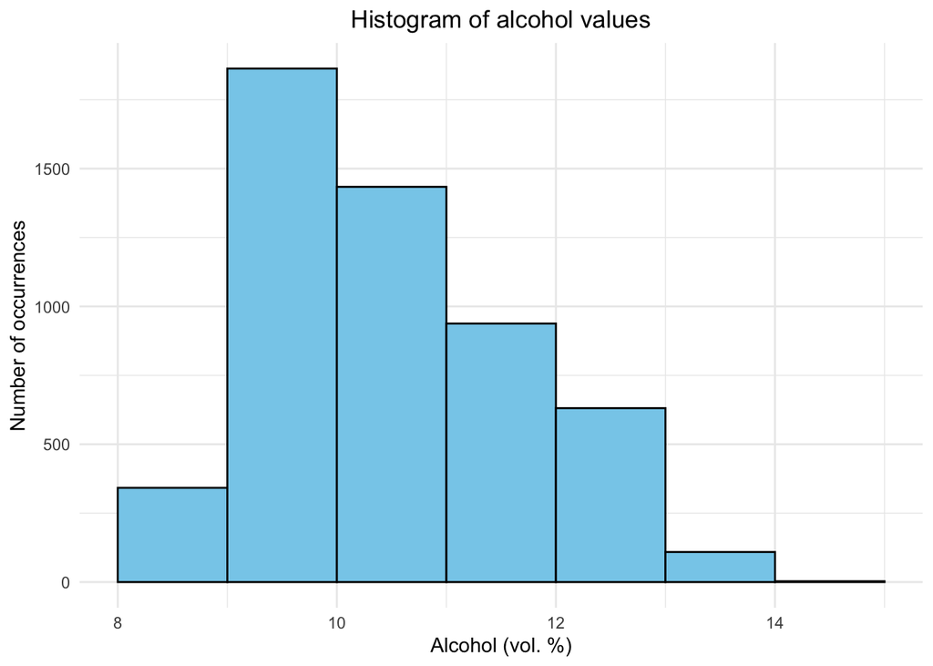

```r
data <- read.csv('winequality-all.csv', skip=5)
ggplot(data, aes(x=alcohol)) +
  geom_histogram(binwidth=1, center = 12.5, fill="skyblue", colour="black") +
  ggtitle("Histogram of alcohol values") +
  theme_minimal() +
  theme(plot.title = element_text(hjust = 0.5)) +
  xlab("Alcohol (vol. %)") +
  ylab("Number of occurrences")
```

This plot shows that the most of vines has from 9 to 10 percent of alcohol. We also see that the distribution is skewed. Alternative for column histogram is estimating the probability density function and plotting that function. Example of doing this is shown on the plot below.

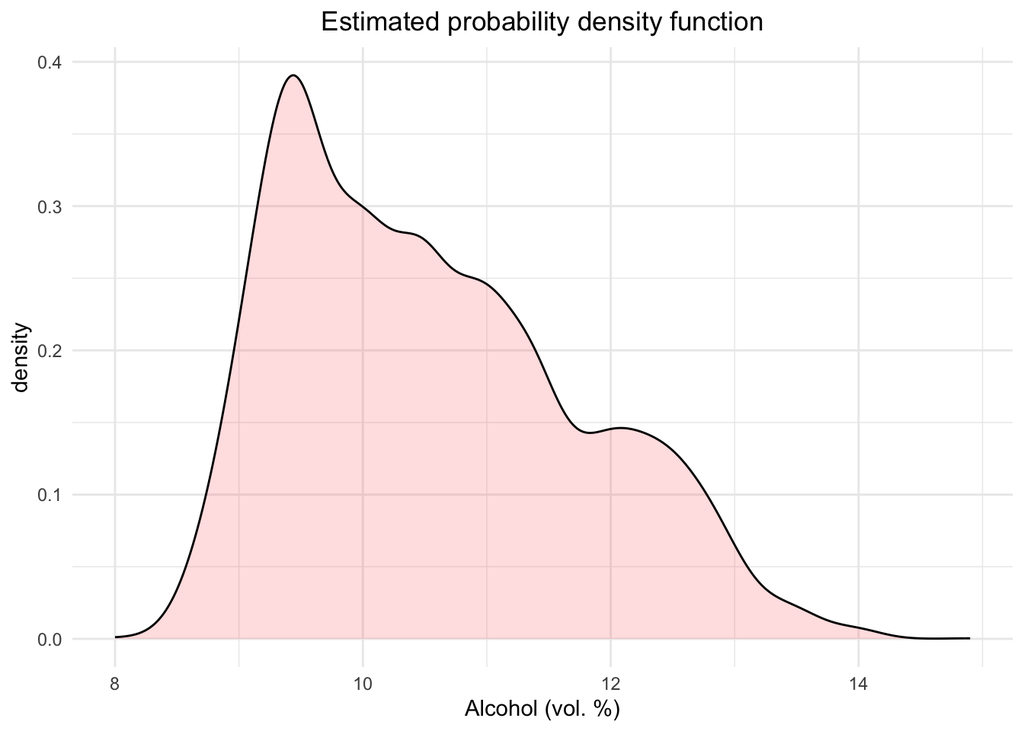

```r
ggplot(data, aes(x=alcohol)) +
  geom_density(alpha=.2, fill="#FF6666") +
  ggtitle("Estimated probability density function") +
  theme_minimal() +
  theme(plot.title = element_text(hjust = 0.5)) +
  xlab("Alcohol (vol. %)")
```

Another alternative for investigating the distribution is boxplot, but we will use it for comparing the distributions.

# Comparing the distribution of alcohol variable between two types of wine i.e. red and white

As mentiond above, first we will use boxplots. They show some basic statistics as median (or mean, or even both), min and max value, first and third quartile, IQR, etc. Also, on boxplots we are able to see outliers.

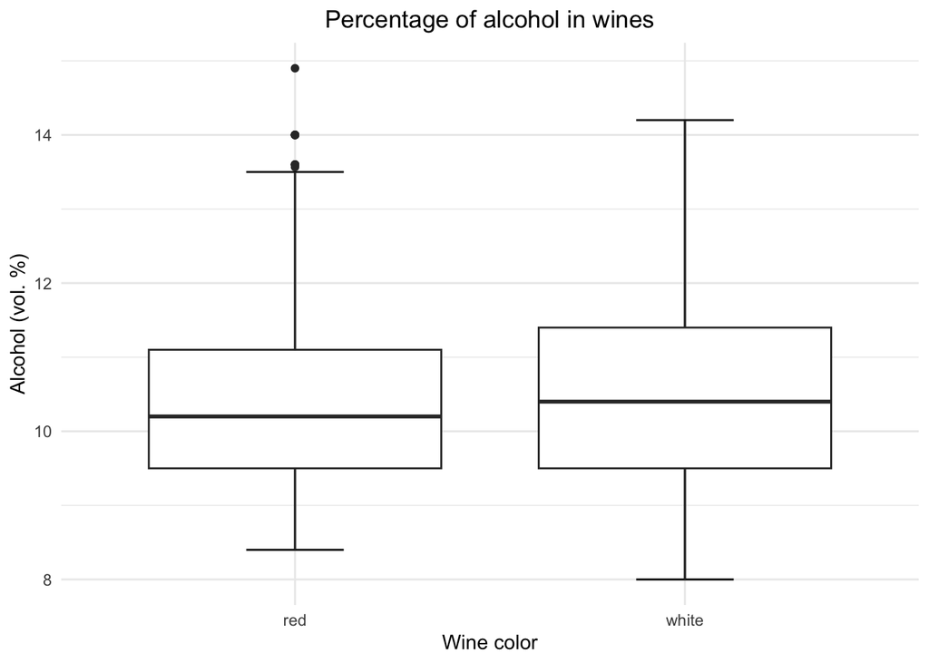

```r
ggplot(data, aes(x=color, y=alcohol)) +
  stat_boxplot(geom = "errorbar", width = 0.25) +
  geom_boxplot() +
  ggtitle("Percentage of alcohol in wines") +
  theme_minimal() +
  theme(plot.title = element_text(hjust = 0.5)) +
  ylab("Alcohol (vol. %)") +
  xlab("Wine color")
```

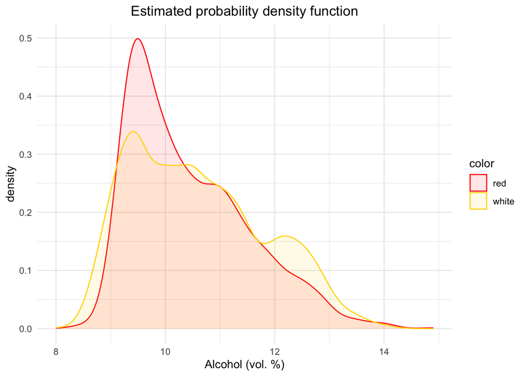

```r
ggplot(data, aes(alcohol, colour = color, fill = color)) +
  geom_density(alpha=0.1) +
  scale_colour_manual(values = c("red","gold")) +
  scale_fill_manual(values = c("red","gold")) +
  ggtitle("Estimated probability density function") +
  theme_minimal() +
  theme(plot.title = element_text(hjust = 0.5)) +
  xlab("Alcohol (vol. %)")
```

We can see that a lot of red wines have around 10% of alocohol, meanwhile estimated density for white wines is more flattened.

Alternative for presented plots are histograms or violin plots, but they show simmilar things - only in a different way.

# Comparing the distribution of alcohol variable in each of possible quality group defined by response variable

First possible to compare the distribution of alcohol variable in each of possible quality is to use the same estimated probability density function as before.

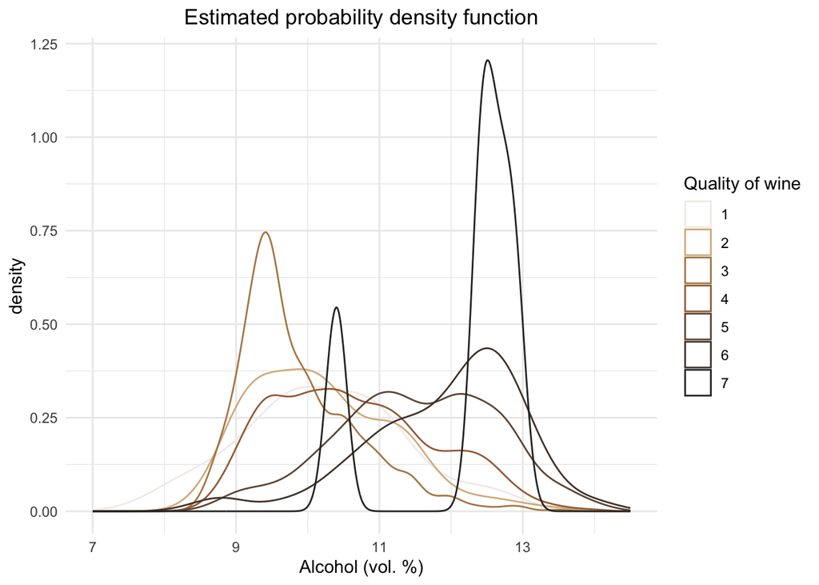

```r
ggplot(data, aes(alcohol, colour = factor(response))) +
  geom_density(alpha=0.2) +
  scale_colour_manual(values = c("#f2edea","#d8b78d", "#b48853",
                               "#a36d46", "#6e5644", "#514036",
                               "#2e2d2c"),
                    name="Quality of wine",
                    labels=1:7) +
  ggtitle("Estimated probability density function") +
  theme_minimal() +
  theme(plot.title = element_text(hjust = 0.5)) +
  xlab("Alcohol (vol. %)") +
  xlim(c(7, 14.5))
```

We can observe that wines with better quality usually have more alcohol. Worse wines (with quality 1-4) usually have from 8 to 12 percentage of alcohol, while better wines (with quality 5-7) have from 10 to 15 percentage of alcohol. Also, the line for wines with quality 7 suggests that there are only few records with such wines in our data set. Used plot is somehow readable (at least for me 🙂), but too much lines can make such plot hard to read. We can use another plot, such as below.

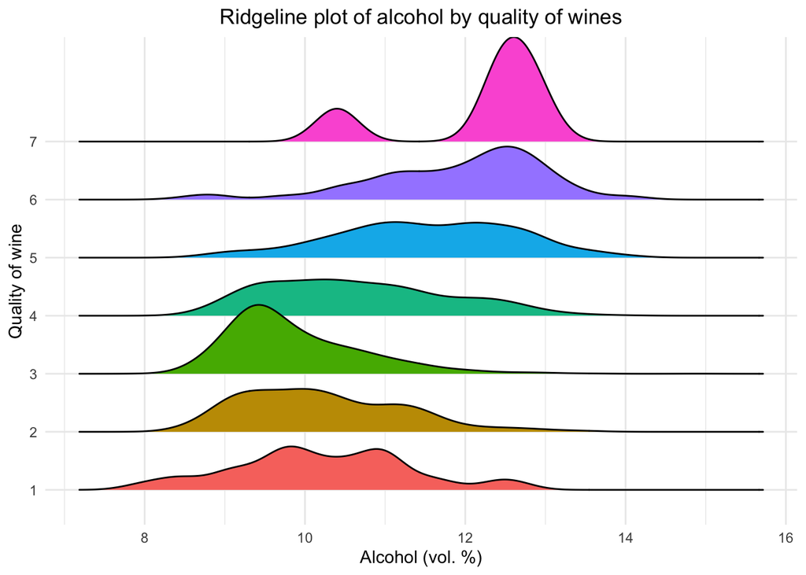

```r
library(ggridges)

ggplot(data, aes(x = alcohol, y = factor(response), fill = factor(response))) +
  geom_density_ridges() +
  #theme_ridges() +
  ggtitle("Ridgeline plot of alcohol by quality of wines") +
  ylab("Quality of wine") +
  theme_minimal() +
  theme(plot.title = element_text(hjust = 0.5)) +
  xlab("Alcohol (vol. %)") +
  theme(legend.position = "none")
```

This type of plot is more easy to read when number of groups is growing, even though it has less details (for example, we don’t have density values on y-axis, as on previous plot). Anyway, here, it is easier to appreciate the different shapes of the distributions. Again, we can observe that better quality wines have more alcohol.

Alternatives that can be used for comparing the distribution of alcohol variable in each of possible quality group are again boxplots, violion charts or histograms (probably to make it readable, one histogram per plot)

# Percentage of red and white wines within each quality group

In this case, simple table does the job.

```r
library(dplyr)
library(knitr)

red <- data %>%
  filter(color == 'red') %>%
  group_by(response) %>%
  count(name = "red_n")

white <- data %>%
  filter(color == 'white') %>%
  group_by(response) %>%
  count(name = "white_n")

df <- white %>%
  left_join(red, by = "response") %>%
  replace(is.na(.), 0) %>%
  mutate(all = white_n + red_n) %>%
  mutate(red = red_n / all * 100) %>%
  mutate(white = white_n / all * 100) %>%
  select(response, all, red, white)

kable(df, align = "cccc", digits = 2)
```

| response | all | red | white |
| --- | --- | --- | --- |
| 1 | 30 | 33.33 | 66.67 |
| 2 | 206 | 25.73 | 74.27 |
| 3 | 1752 | 32.93 | 67.07 |
| 4 | 2323 | 23.03 | 76.97 |
| 5 | 856 | 19.51 | 80.49 |
| 6 | 148 | 11.49 | 88.51 |
| 7 | 5 | 0.00 | 100.00 |

We can see for every response (i.e. quality of wine) how many wines are in our dataset (column “all”) and the percentage of red and white wines for every response. For example, we cen see that in better quality wines there is greater percentage of white wines that in group of worse quality wines. Anyway, we can present this data with plot to make it more pleasant for eyes. The good type of plot to this is stacked barplot.

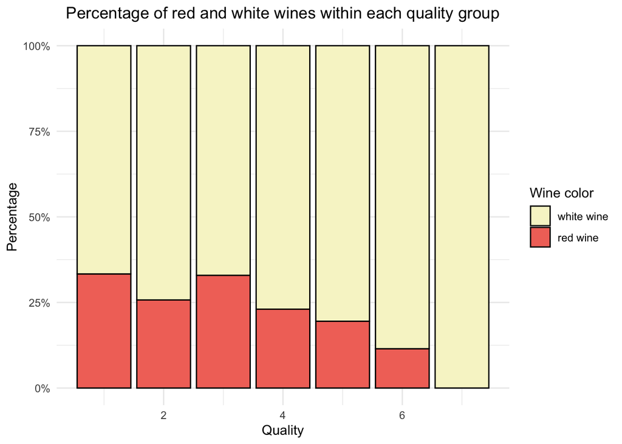

```r
df <- data %>%
  group_by(response, color) %>%
  count()

ggplot(df, aes(fill=factor(color, levels=c("white", "red")),
               y=n, x=response)) +
  geom_bar(position="fill", stat="identity", colour="black") +
  ggtitle("Percentage of red and white wines within each quality group") +
  scale_fill_manual(values = c("#f7f4cd", "#f27468"),
                      name="Wine color",
                      labels=c("white wine", "red wine")) +
  scale_y_continuous(labels = scales::percent) +
  ylab("Percentage") +
  theme_minimal() +
  theme(plot.title = element_text(hjust = 0.5)) +
  xlab("Quality")
```

As it was said before, we can observe that better wines have greater percentage of white wines. Also, our data set contains more white than red wines. Alternative for this plot is also stacked bar plot, but bars can be with height correlating with number of specified wines, not with the percentage. Percentage can be only written on every bar - in this case we can have information about number of wines for every quality, as it is missing on the plot above. Anyway, then it is harder to compare heights of bars in case of comparing percentages - we would be able only to read them.

# Investigating the relationship between variables describing acidity of the wines

To investigate the relationship between two variables the best plot is scatter plot. On this type of plots, we can observe how the data is distributed (i.e. where there is a high density of points). Also we can see whether there is the correlation between the variables and if there is, what type of correlation (positive, negative, strong, weak, etc.).

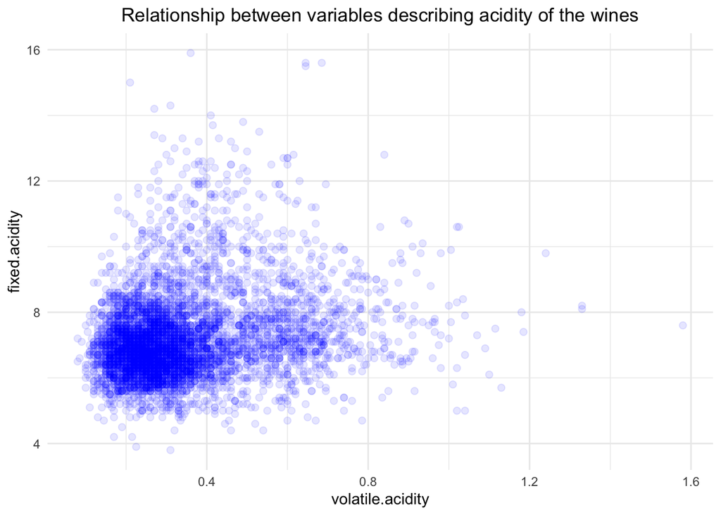

```r
ggplot(data, aes(x=volatile.acidity, y=fixed.acidity)) +
  geom_point(size=2, alpha=0.1, color='blue') +
  ggtitle("Relationship between variables describing acidity of the wines") +
  ylab("fixed.acidity") +
  theme_minimal() +
  theme(plot.title = element_text(hjust = 0.5)) +
  xlab("volatile.acidity")
```

I wouldn’t say that there is a correlation between these two variables. Anyway, we can observe that most points are accumulated in a rectangle [0.1, 0.4] x [6, 8]. To investigate the relationships between more variables it is good to plot heat map with correlations for every pair of variables. In our case, we can calculate this correlation, but we don’t need a plot to show only one value.

```r
cor(data$volatile.acidity, data$fixed.acidity)
```

```
## [1] 0.2147521
```

Value 0.21 can be interpreted that there is a very weak positive correlation between volatile.acidity and fixed.acidity.